# Take Home Exam -- Thanks COVID-19

```python
!jupyter nbconvert --to script exam.ipynb
!jupyter nbconvert --to html exam.ipynb
```

[output not shown]

```python
import numpy as np
import matplotlib.pyplot as plt
import scipy.spatial; import scipy as spy

# interactive images
# %matplotlib widget
# static inline images
%matplotlib inline
%config InlineBackend.figure_format = "png"
import matplotlib as mpl
mpl.rcParams["figure.dpi"]= 300
```

## NURBS Surface

$P(u, v) = \frac{ \sum_{i = 0}^{1} \sum_{j = 0}^{2} h_{i,j} * P_{i, j} * N_{i, 2}(u) * N_{j, 3}(v) }{ \sum_{i = 0}^{1} \sum_{j = 0}^{2} h_{i, j} * N_{i, 2}(u) * N_{j, 3}(v) }$

### Plot the NURBS Surface

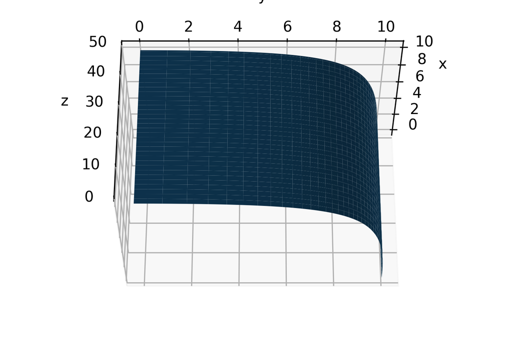

```python
def NSubISub2(i: int, u: float) -> float:
    """Basis function along u direction."""
    if i == 0:
        return (1-u if u >= 0 and u <= 1 else 0)
    elif i == 1:
        return (u if u >= 0 and u <= 1 else 0)
    else:
        raise IndexError(f"i = {i} is not within the bounds of this basis function")

def NSubJSub3(j: int, v: float) -> float:
    """Basis function along v direction."""
    if j == 0:
        return ((1-v)**2 if v >= 0 and v <= 1 else 0)
    elif j == 1:
        return (2*v*(1-v) if v >= 0 and v <= 1 else 0)
    elif j == 2:
        return (v**2 if v >= 0 and v <= 1 else 0)
    else:
        raise IndexError(f"i = {i} is not within the bounds of this basis function")

P = np.array([ # control points
    [[10, 0, 0], [10, 10, 0], [0, 10, 0]],
    [[10, 0, 50], [10, 10, 50], [0, 10, 50]],
])

def HSubISubJ(i: int, j: int) -> int:
    """Weighting factors for a given i, j."""
    HSubI = np.array([1, 1])
    HSubJ = np.array([1, 2, 1])
    return HSubI[i]*HSubJ[j]

def nurbs_func(u, v):
    """Summation series for each i, j for a given u, v input."""
    num, den = 0, 0
    for i in range(2):
        for j in range(3):
            num += HSubISubJ(i, j)*P[i, j]*NSubISub2(i, u)*NSubJSub3(j, v)
            den += HSubISubJ(i, j)*NSubISub2(i, u)*NSubJSub3(j, v)
    return num / den

start = 0
stop = 1
step = .01
u = np.arange(start, stop + step, step)
v = u.copy()

POut = np.zeros((len(u), len(v), 3))
for iu, uu in enumerate(u):
    for iv, vv in enumerate(v):
        POut[iu, iv] = nurbs_func(uu, vv)

# plot surface
fig = plt.figure(1)
ax = plt.axes(projection="3d")
ax.plot_surface(POut[:, :, 0], POut[:, :, 1], POut[:, :, 2])
ax.set_xlabel("x")
ax.set_ylabel("y")
ax.set_zlabel("z")
ax.view_init(-30, 0)
plt.show()
```

## VTA Chordal Error

### Plot the STL facet

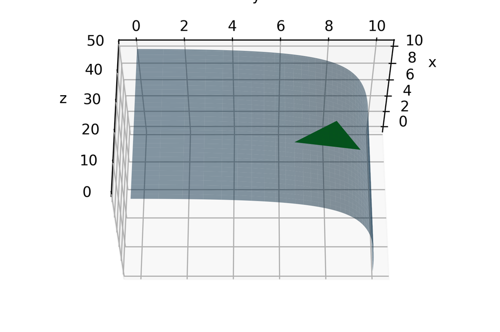

```python
faceUV = np.array([
    [0.4, 0.3],
    [0.6, 0.5],
    [0.5, 0.7],
])
V = np.array([ # vertexes on STL facet
    nurbs_func(*faceUV[0, :]),
    nurbs_func(*faceUV[1, :]),
    nurbs_func(*faceUV[2, :]),
])

fig = plt.figure(2)
ax = plt.axes(projection="3d")
ax.plot_surface(POut[:, :, 0], POut[:, :, 1], POut[:, :, 2], alpha=0.5)
ax.plot_trisurf(V[:, 0], V[:, 1], V[:, 2], color="g")
ax.set_xlabel("x")
ax.set_ylabel("y")
ax.set_zlabel("z")
ax.view_init(-30, 0)
plt.show()
```

### Generate R

```python
A = faceUV[0, :]
B = faceUV[1, :]
C = faceUV[2, :]
step = .01
t = np.arange(0, 1+step, step)
AB = np.array([A + tt * (B - A) for tt in t])
AC = np.array([A + tt * (C - A) for tt in t])

s = t.copy()
R = np.zeros((len(t), len(s), 2))
for i, tt in enumerate(t):
    for j, ss in enumerate(s):
        R[i, j, :] = AB[i, :] + ss * (AC[i, :] - AB[i, :])
```

- sanity check

```python
print(np.all(R[0, 0, :] == AB[0, :])) # start of AB
print(np.all(R[-1, 0, :] == AB[-1, :])) # end of AB
print(np.all(R[0, -1, :] == AC[0, :])) # start of BC
print(np.all(R[-1, -1, :] == AC[-1, :])) # end of BC
```

```
True
True
True
True
```

### Generate $P_{CAD}$

- In $X$, $Y$, $Z$ space:
  - $P_{CAD}$ is the analogous NURBS points corresponding to $R$ on the STL surface
  - $A$, $B$, $C$ correspond to 3 vertices of the facet
  - $n$ and $u$ are the the normal and unit normal vectors, respectively

```python
PSubCAD = np.zeros((R.shape[0], R.shape[1], 3))
for i in range(R.shape[0]):
    for j in range(R.shape[1]):
        PSubCAD[i, j, :] = nurbs_func(*R[i, j, :])

A = V[0, :]
B = V[1, :]
C = V[2, :]
n = np.cross(B-A, C-A) # AB x AC
u = n / np.linalg.norm(n)
```

- view the normal direction

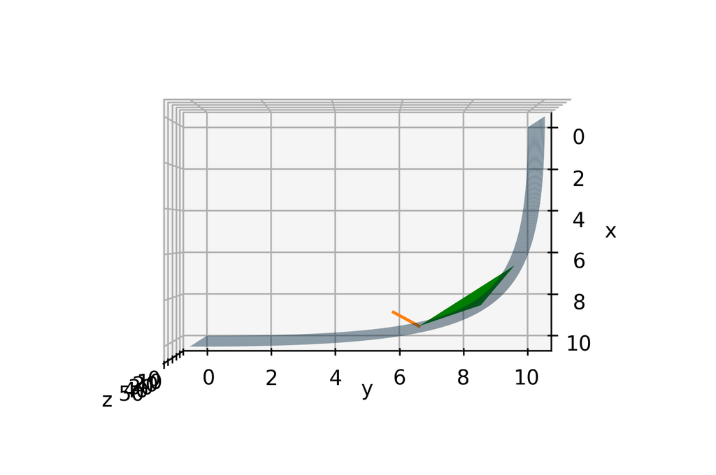

```python
fig = plt.figure(3)
ax = plt.axes(projection="3d")
ax.plot_surface(POut[:, :, 0], POut[:, :, 1], POut[:, :, 2], alpha=0.5)
ax.plot_trisurf(V[:, 0], V[:, 1], V[:, 2], color="g")
temp = np.array([V[0, :], V[0, :] + 1*u])
ax.plot(temp[:, 0], temp[:, 1], temp[:, 2])
ax.set_xlabel("x")
ax.set_ylabel("y")
ax.set_zlabel("z")
ax.view_init(90, 0)
plt.show()
```

### Generate $P_{STL}$

- Find intersection on STL facet of line extending from $P_{CAD}$ parallel to unit normal, $u$ of STL facet
  - We cannot assume that points on $P_{CAD}$ projects on $P_{STL}$ are inside the triangle; we must do inside poly test
  - Eqn of line: $R = R_0 + \lambda u$
    - $R_0$ being point on $P_{CAD}$
    - $\lambda = \frac{ - (n_xR_{0x} + n_yR_{0y} + n_yR_{0z}) }{ n_xu_x + n_yu_y + n_zu_z }$
    - $n$ being the normal vector of $P_{STL}$
    - $u$ being the unit normal of $P_{STL}$

```python
ASubABC = 0.5 * np.dot(n, np.cross(B-A, C-A))
PSubSTL = np.zeros((R.shape[0], R.shape[1], 3))
for i in range(R.shape[0]):
    for j in range(R.shape[1]):
        _lambda = - np.dot(n, PSubCAD[i, j, :]) / np.dot(n, u)
        print(_lambda)
        D = PSubCAD[i, j, :] + _lambda * u
        ASubABD = 0.5 * np.dot(n, np.cross(B-A, D-A)) # AB x AD
        ASubBCD = 0.5 * np.dot(n, np.cross(C-B, D-B)) # BC x BD
        ASubADC = 0.5 * np.dot(n, np.cross(D-A, C-A)) # AD x AC
        if np.isclose(ASubABC, np.sum([ASubABD, ASubBCD, ASubADC])):
            PSubSTL[i, j, :] = D
        else:
            PSubSTL[i, j, :] = np.zeros((1, 3))
```

[output not shown]

[output cut: 10146 more lines]

[output not shown]

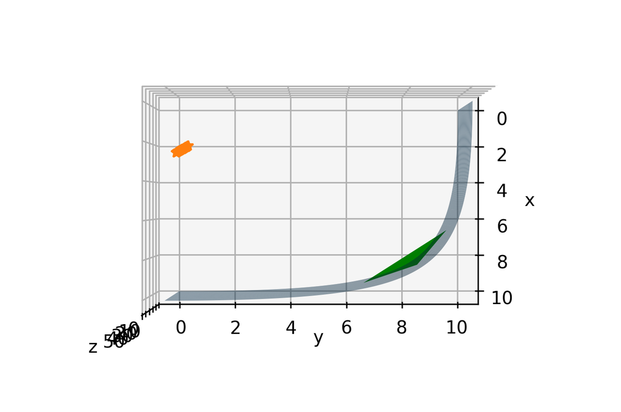

```python
fig = plt.figure(4)
ax = plt.axes(projection="3d")
ax.plot_surface(POut[:, :, 0], POut[:, :, 1], POut[:, :, 2], alpha=0.5)
ax.plot_trisurf(V[:, 0], V[:, 1], V[:, 2], color="g")
temp = np.array([V[0, :], V[0, :] + 1*u])
ax.plot(PSubSTL[40:60, 49, 0], PSubSTL[40:60, 49, 1], PSubSTL[40:60, 49, 2], '*')
ax.set_xlabel("x")
ax.set_ylabel("y")
ax.set_zlabel("z")
ax.view_init(90, 0)
plt.show()
```

```python
PSubSTL[40:60, 49, :]
```

```
array([[ 2.45545905,  0.1271572 , 23.7194412 ],
       [ 2.4372868 ,  0.14932802, 23.79516894],
       [ 2.41913879,  0.17147703, 23.87087995],
       [ 2.40101343,  0.19360554, 23.94657433],
       [ 2.38290916,  0.21571489, 24.02225213],
       [ 2.36482439,  0.23780641, 24.09791343],
       [ 2.34675756,  0.2598814 , 24.17355829],
       [ 2.32870711,  0.28194118, 24.24918677],
       [ 2.31067148,  0.30398706, 24.32479893],
       [ 2.29264913,  0.32602033, 24.40039483],
       [ 2.27463851,  0.34804229, 24.47597452],
       [ 2.25663808,  0.37005425, 24.55153806],
       [ 2.2386463 ,  0.39205748, 24.6270855 ],
       [ 2.22066164,  0.41405328, 24.70261688],
       [ 2.20268257,  0.43604293, 24.77813225],
       [ 2.18470757,  0.45802771, 24.85363166],
       [ 2.1667351 ,  0.4800089 , 24.92911514],
       [ 2.14876365,  0.50198778, 25.00458274],
       [ 2.1307917 ,  0.52396562, 25.08003449],
       [ 2.11281772,  0.54594371, 25.15547041]])
```

### Find Error between $P_{CAD}$ and $P_{STL}$ via Euclidean Distance

```python
errCh = np.zeros((R.shape[0], R.shape[1]))
for i in range(R.shape[0]):
    for j in range(R.shape[1]):
        if np.all( PSubSTL[i, j, :] != np.zeros((1, 3)) ):
            errCh[i, j] = spy.spatial.distance.euclidean(PSubSTL[i, j, :], PSubCAD[i, j, :])

errChSubMaxLoc = np.unravel_index(np.argmax(errCh), errCh.shape)
errChSubMax = errCh[errChSubMaxLoc]
PSubSTLSubMax = PSubSTL[errChSubMaxLoc]
PSubCADSubMax = PSubCAD[errChSubMaxLoc]
print(f"The location of the maximum chordal error is {PSubSTLSubMax}\nThe maximum chordal error is {errChSubMax}.")
V
```

```
The location of the maximum chordal error is [ 1.85107546  0.58624466 23.21258073]
The maximum chordal error is 10.126441692777787.
```

```
array([[ 9.36619718,  6.54929577, 20.        ],
       [ 8.33333333,  8.33333333, 30.        ],
       [ 6.54929577,  9.36619718, 25.        ]])
```

```python
PSubSTL
```

```
array([[[ 3.22177686, -0.79403584, 20.67544298],
        [ 3.22177686, -0.79403584, 20.67544298],
        [ 3.22177686, -0.79403584, 20.67544298],
        ...,
        [ 3.22177686, -0.79403584, 20.67544298],
        [ 3.22177686, -0.79403584, 20.67544298],
        [ 3.22177686, -0.79403584, 20.67544298]],

       [[ 3.21017701, -0.77509297, 20.77586513],
        [ 3.20999367, -0.77498448, 20.77537673],
        [ 3.20981033, -0.774876  , 20.77488832],
        ...,
        [ 3.19223102, -0.76447986, 20.72799703],
        [ 3.19204812, -0.76437176, 20.72750853],
        [ 3.19186522, -0.76426365, 20.72702003]],

       [[ 3.19862197, -0.75618851, 20.87627728],
        [ 3.19825619, -0.75597231, 20.87530027],
        [ 3.19789042, -0.75575613, 20.87432327],
        ...,
        [ 3.16285822, -0.73507226, 20.78051213],
        [ 3.16249414, -0.73485752, 20.77953474],
        [ 3.16213007, -0.7346428 , 20.77855735]],

       ...,

       [[ 2.20868912,  0.95512651, 30.47618487],
        [ 2.19238055,  0.96429925, 30.42755276],
        [ 2.17606556,  0.97347674, 30.37891389],
        ...,
        [ 0.50928176,  1.93566194, 25.67714722],
        [ 0.49004386,  1.94722038, 25.6278043 ],
        [ 0.4707473 ,  1.95882711, 25.57845283]],

       [[ 2.19880441,  0.97256164, 30.57581744],
        [ 2.18232277,  0.98183291, 30.52668208],
        [ 2.16583413,  0.99110939, 30.47753984],
        ...,
        [ 0.47710962,  1.96713963, 25.72670281],
        [ 0.45755463,  1.97891547, 25.67683883],
        [ 0.43793824,  1.99074186, 25.62696602]],

       [[ 2.18891301,  0.99000172, 30.67544298],
        [ 2.17225771,  0.999372  , 30.62580424],
        [ 2.1555948 ,  1.00874799, 30.57615847],
        ...,
        [ 0.44469499,  1.998817  , 25.77622327],
        [ 0.42481734,  2.01081483, 25.72583768],
        [ 0.40487545,  2.02286557, 25.67544298]]])
```

```python
V
```

```
array([[ 9.36619718,  6.54929577, 20.        ],
       [ 8.33333333,  8.33333333, 30.        ],
       [ 6.54929577,  9.36619718, 25.        ]])
```

```python
PSubCAD
```

```
array([[[ 9.36619718,  6.54929577, 20.        ],
        [ 9.35843758,  6.57282821, 20.1       ],
        [ 9.35063183,  6.59621352, 20.2       ],
        ...,
        [ 8.35985834,  8.30652387, 29.8       ],
        [ 8.34663118,  8.31996437, 29.9       ],
        [ 8.33333333,  8.33333333, 30.        ]],

       [[ 9.35843758,  6.57282821, 20.1       ],
        [ 9.35063183,  6.59621352, 20.1985    ],
        [ 9.34277981,  6.61945298, 20.297     ],
        ...,
        [ 8.34663118,  8.31996437, 29.753     ],
        [ 8.33333333,  8.33333333, 29.8515    ],
        [ 8.31996437,  8.34663118, 29.95      ]],

       [[ 9.35063183,  6.59621352, 20.2       ],
        [ 9.34277981,  6.61945298, 20.297     ],
        [ 9.33488143,  6.64254785, 20.394     ],
        ...,
        [ 8.33333333,  8.33333333, 29.706     ],
        [ 8.31996437,  8.34663118, 29.803     ],
        [ 8.30652387,  8.35985834, 29.9       ]],

       ...,

       [[ 8.35985834,  8.30652387, 29.8       ],
        [ 8.34663118,  8.31996437, 29.753     ],
        [ 8.33333333,  8.33333333, 29.706     ],
        ...,
        [ 6.64254785,  9.33488143, 25.194     ],
        [ 6.61945298,  9.34277981, 25.147     ],
        [ 6.59621352,  9.35063183, 25.1       ]],

       [[ 8.34663118,  8.31996437, 29.9       ],
        [ 8.33333333,  8.33333333, 29.8515    ],
        [ 8.31996437,  8.34663118, 29.803     ],
        ...,
        [ 6.61945298,  9.34277981, 25.147     ],
        [ 6.59621352,  9.35063183, 25.0985    ],
        [ 6.57282821,  9.35843758, 25.05      ]],

       [[ 8.33333333,  8.33333333, 30.        ],
        [ 8.31996437,  8.34663118, 29.95      ],
        [ 8.30652387,  8.35985834, 29.9       ],
        ...,
        [ 6.59621352,  9.35063183, 25.1       ],
        [ 6.57282821,  9.35843758, 25.05      ],
        [ 6.54929577,  9.36619718, 25.        ]]])
```

```python
PSubSTL
```

```
array([[[ 3.22177686, -0.79403584, 20.67544298],
        [ 3.22177686, -0.79403584, 20.67544298],
        [ 3.22177686, -0.79403584, 20.67544298],
        ...,
        [ 3.22177686, -0.79403584, 20.67544298],
        [ 3.22177686, -0.79403584, 20.67544298],
        [ 3.22177686, -0.79403584, 20.67544298]],

       [[ 3.21017701, -0.77509297, 20.77586513],
        [ 3.20999367, -0.77498448, 20.77537673],
        [ 3.20981033, -0.774876  , 20.77488832],
        ...,
        [ 3.19223102, -0.76447986, 20.72799703],
        [ 3.19204812, -0.76437176, 20.72750853],
        [ 3.19186522, -0.76426365, 20.72702003]],

       [[ 3.19862197, -0.75618851, 20.87627728],
        [ 3.19825619, -0.75597231, 20.87530027],
        [ 3.19789042, -0.75575613, 20.87432327],
        ...,
        [ 3.16285822, -0.73507226, 20.78051213],
        [ 3.16249414, -0.73485752, 20.77953474],
        [ 3.16213007, -0.7346428 , 20.77855735]],

       ...,

       [[ 2.20868912,  0.95512651, 30.47618487],
        [ 2.19238055,  0.96429925, 30.42755276],
        [ 2.17606556,  0.97347674, 30.37891389],
        ...,
        [ 0.50928176,  1.93566194, 25.67714722],
        [ 0.49004386,  1.94722038, 25.6278043 ],
        [ 0.4707473 ,  1.95882711, 25.57845283]],

       [[ 2.19880441,  0.97256164, 30.57581744],
        [ 2.18232277,  0.98183291, 30.52668208],
        [ 2.16583413,  0.99110939, 30.47753984],
        ...,
        [ 0.47710962,  1.96713963, 25.72670281],
        [ 0.45755463,  1.97891547, 25.67683883],
        [ 0.43793824,  1.99074186, 25.62696602]],

       [[ 2.18891301,  0.99000172, 30.67544298],
        [ 2.17225771,  0.999372  , 30.62580424],
        [ 2.1555948 ,  1.00874799, 30.57615847],
        ...,
        [ 0.44469499,  1.998817  , 25.77622327],
        [ 0.42481734,  2.01081483, 25.72583768],
        [ 0.40487545,  2.02286557, 25.67544298]]])
```